# Assignment2

Carl Xi

10/26/2019

Initial Setup

```r
########## Empirical Assignment 2 ##########

#Cleaning workspace of any variables
#rm(list = ls(all = TRUE))

# Loading packages
library(data.table)
library(igraph)
library(readxl)
library(tidyr)
library(stringr)
library(lubridate)
library(ggplot2)
library(dplyr)
library(network)
library(plotly)
library(splitstackshape)
library(zoo)
#Setting file path
setwd("C:/Users/carlj/OneDrive/Documents/School-MSBA/Classes/Fall/Social Network Analytics/Assignment 2")

#Loading Data
FEP1 <- read.csv('Funding_events_7.14.csv')
FEP2 <- read_xlsx('Funding_events_7.14_page2.xlsx')
VC <- read.csv('Venture_capital_firm_outcomes.csv')

#Standardizing Colnames
colnames(FEP1) <- colnames(FEP2)

#Standardizing Dates and binding the two Funding datasets together
FEP1$`Deal Date`<-as.Date(FEP1$`Deal Date`,'%m/%d/%y')
FEP2$`Deal Date`<-as.Date(FEP2$`Deal Date`,'%y-%m-%d')
FundEvent <- rbind(FEP1,FEP2)

#Change Investor variables into string and order by deal date
FundEvent$Investors <- as.character(FundEvent$Investors)
FundEvent <- FundEvent[order(FundEvent$`Deal Date`),]

#Generating Network into dataframe and removing all empty and NA rows
#Also removing firms with only 1 investor
Network <- data.frame(Investor = as.character(FundEvent$Investors[FundEvent$Investors != "" & !is.na(FundEvent$Investors)]),date = FundEvent$`Deal Date`[FundEvent$Investors != "" & !is.na(FundEvent$Investors)])

#Checking the dimensions of the dataset
dim(Network)
```

```
## [1] 54477     2
```

```r
#drop rows with only 1 investor
Network$filter <- str_detect(Network$Investor, ', ', negate = FALSE)
Network <- Network[Network$filter==TRUE,]

#Removing all Inc etc suffixes from firm names from Network dataset
Network$Investor <- gsub(', Inc[.]|, Inc|, LLC|, llc|, L[.]L[.]C|, L[.]L[.]C[.]|, LTD|, Ltd|, Ltd[.]|,Ltd|, Co|, Corp|, LP|, L[.]P|, Limited[.]|, LA|[.]*' , '',as.character(Network$Investor))

#Removing all Inc etc suffixes from firm names from the VC dataset
VC$firm_name <- gsub(', Inc[.]|, Inc|, LLC|, llc|, L[.]L[.]C|, L[.]L[.]C[.]|, LTD|, Ltd|, Ltd[.]|,Ltd|, Co|, Corp|, LP|, L[.]P|, Limited[.]|, LA|[.]*' , '',as.character(VC$firm_name))

###############splitting investors############################
NtwkList <- strsplit(Network$Investor,split=',')

#Further cleaning Network list by subsetting
Select <- lapply(NtwkList,length)>1
NtwkList <- NtwkList[Select]
NtwkDate <- Network$date[Select]
NtwkCombined <- lapply(NtwkList, combn,m=2)
NtwkDateNum <-  matrix(unlist(lapply(NtwkCombined,dim)),ncol=2,byrow=TRUE)[,2]

#Finalizing network dates
NtwkDate <- rep(NtwkDate,NtwkDateNum)

#Full Edge List
NtwkEdgeList <- matrix(unlist(NtwkCombined), ncol = 2, byrow = TRUE)
NtwkEdgeList <- apply(NtwkEdgeList,2,str_trim,side='both')
NtwkWhole <- cbind(NtwkEdgeList,NtwkDate)

#Remove Duplicates to create final clean edge list
Select <- !duplicated(lapply(as.data.frame(t(NtwkEdgeList), stringsAsFactors=FALSE), sort))
EdgeListClean <- NtwkEdgeList[Select,]
EdgeListClean <- unique(EdgeListClean)
```

Question 1

First, perform the Kevin Bacon Hollywood Actor exercise on the venture capital firm network.

```r
#Generating Graph of clean network
NtwkClean = graph_from_edgelist(EdgeListClean,directed = FALSE)
```

1. Which ﬁrm is the center of the venture capital ﬁrm network as of July 2014? Consider the most central ﬁrm to be the ﬁrm with the largest closeness centrality, as in the Hollywood Actor example.

```r
#We are Looking for the firm with the the lar
suppressWarnings(which(closeness(NtwkClean,vids = V(NtwkClean))== max(closeness(NtwkClean,vids = V(NtwkClean)))))
```

```
## Intel Capital
##           415
```

```r
suppressWarnings(Node <- list(V(NtwkClean)))
suppressWarnings(max(closeness(NtwkClean,vids = V(NtwkClean))))
```

```
## [1] 1.496052e-07
```

A: Intel Capital is the most central firm within this network with the largest closeness value at 1.496*10^-7

2. Next, compute the average shortest path length between all ﬁrms in the July 2014 network and verify that the ﬁrm with the highest closeness centrality also has the lowest average path distance. You can consider nodes that are unreachable to be separated by a number of steps equal to the total number of the ﬁrms in the network.

```r
#Creating distance table from cleaned network
Distance <- distances(NtwkClean,v = V(NtwkClean))

#Checking the dimensions of distance
dim(Distance)
```

```
## [1] 12878 12878
```

```r
#Replaced all Infinite (unreachable) distances with the dimension of distance, which is also the total number of firms in our network
Distance[Distance==Inf] = dim(Distance)

#Checking if Intel Capital is also the firm with the lowest average path distance
mean(Distance['Intel Capital',]) == min(apply(Distance,1,mean))
```

```
## [1] TRUE
```

Our boolean call returned True. This is good news as this means that the ﬁrm with the highest closeness centrality (Intel Capital) also has the lowest average path distance in our July 2014 network.

3. What is the average shortest path length for all ﬁrms? Why is this number so high?

```r
#Getting the average
mean(Distance)
```

```
## [1] 1016.335
```

```r
#Looking for the total number of pairs of unreachable firms. We divided by two because each pair is counted twice for back and forth.
sum(distances(NtwkClean) == Inf)/2
```

```
## [1] 6523668
```

Question2

Next, we will look at the development of the local group membership of the co-investment network over time. Allow the network to be updated monthly for each month t in the data, adding the new ties that occur through investments in the current month to be added to the existing network of ties that have occurred in previous months. In Class Session 3, a ﬁgure on Slide 59 plotted over time the industry average of the highestdegree k-core each venture capital ﬁrm in the co-investment network belonged to. When a node is a member of a k-core with a high degree, its surrounding ties are very dense. When many nodes are members of k-cores with high degrees, this suggests that there may exist dense clusters within the network.

1. ConstructaﬁguresimilartoClassSession3’s, plotting the average k-core of eachventure capital ﬁrm in the network over time. This can be computed using the igraph function coreness. On the x-axis should be time. On the y-axis should be the highest-degree k-core each venture capital ﬁrm belongs to, averaged over all ﬁrms in the network up to that month.

```r
#Create edgelist table with dates
WholeNtwkv1 <- as.data.table(EdgeListClean)
WholeNtwkv1 <- cbind(WholeNtwkv1,NtwkDate)
```

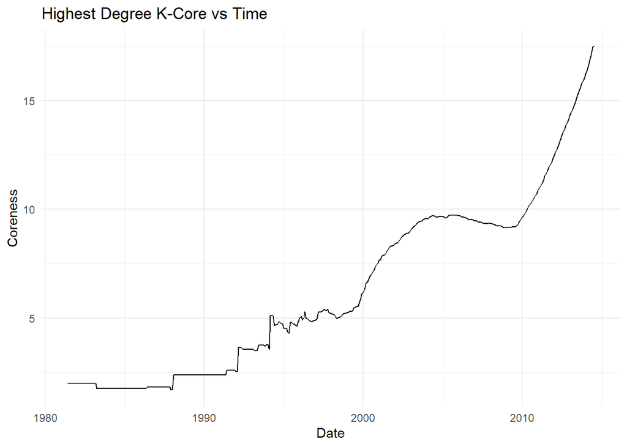

```r
WholeNtwkv1 <- WholeNtwkv1[order(WholeNtwkv1$NtwkDate),]
WholeNtwkv2 <- WholeNtwkv1

#we need monthly data, so we converted the date into yearmonth variables using the zoo package
WholeNtwkv2$yearmon <- as.yearmon(as.character(WholeNtwkv2$NtwkDate))

#create a list of months where deals occur
MonthList <- unique(WholeNtwkv2$yearmon)
MonthList <- sort(MonthList)

#Get the total number of months where deals occur
X <- length(unique(WholeNtwkv2$yearmon))

#Finding out the total length of months from the first to last month
Length <- as.integer(-1*(MonthList[1]-MonthList[253])*12+1)

#creating a dataframe for the graph to plot, with months and coreness calculated at every month
DataFrame1 <- data.frame()
Result <- data.frame()
for(i in 0:Length){
  Mnth <- MonthList[1]+i*(1/12)
  DataFrame1 <- WholeNtwkv2[(WholeNtwkv2$yearmon<=Mnth)][,1:2]
  Ntwk <- graph.data.frame(DataFrame1,directed=FALSE)
  Coreness1 <- mean(coreness(Ntwk))
  Row <- data.frame(Mnth,Coreness1)
  Result <- rbind(Result,Row)
}

#plot out the graph using ggplot
ggplot() + geom_line(aes(y=Result$Coreness1, x=Result$Mnth)) + labs(title ="Highest Degree K-Core vs Time", x = "Date", y = "Coreness") + theme_minimal()
```

2. Construct a plot similar to (A), but only consider unique ties as opposed to repeated ties in the calculation. Does the ﬁgure appear different than before? What does this suggest about the nature of relationships in the co-investment network?

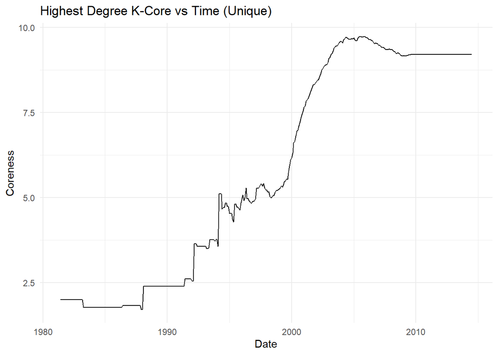

```r
#creating a dataframe for the graph to plot, with months and coreness calculated at every month
DataFrame2 <- data.frame()
Result1 <- data.frame()
for(i in 0:Length){
  Mnth <- MonthList[1]+i*(1/12)
  DataFrame2 <- WholeNtwkv2[(WholeNtwkv2$yearmon<=Mnth)][,1:2]
  DataFrame2 <- unique(DataFrame2)
  Ntwk <- graph.data.frame(DataFrame2,directed=FALSE)
  Coreness1 <- mean(coreness(Ntwk))
  Row <- data.frame(Mnth,Coreness1)
  Result1 <- rbind(Result1,Row)
}

#plot out the graph using ggplot
ggplot() + geom_line(aes(y=Result1$Coreness1, x=Result1$Mnth)) + labs(title ="Highest Degree K-Core vs Time (Unique)", x = "Date", y = "Coreness") + theme_minimal()
```

While Plots a and b have relatively similar trends, there are some notable differences. Most notably, chart b flattened out after 2008 while chart a shot up drastically, to even above 17 or 18 by 2014. In fact, chart b never went above 10 in terms of coreness at all. With b (unique) being much lower than the normal graph (a), this means that the partnerhips are highly repetitive. This offers several interesting observations from a behavioral standpoint.

For one, people tend to like working with people they have preivously conducted a deals with, and this is certinaly the case here. After 2008’s financial crisis, it makes sense for people to be wary of working with foreign firms and instead work with trustworthy partners. Additionally, people like working with others who have a similar investment style/preference, and thus it would make sense for firms to work with the same few partners instead of actively trying to diversify their partnership network.

In addition, the rapid growth in coreness after 2008 for plot a is a stark contrast to the pleateau in plot b. This also hints at the idea that many firms went bankrupt or closed after the crisis, while total investments stayed around the same or even rose. This made the already strong firms that survived the crisis even more appealing investors, strengthening them and making the coreness stronger.

Lastly, with the rapid financial and technological growth after the dot-com bubble, places like silicon valley grew significantly. Many new investors and firms were created to meet this boom in investment demand, thus many new partnerships were created, which should’ve driven some local density growth.

3. Construct a plot similar to (A), but now allow ties to “decay.” Remove ties from the network if they are not renewed within 5 years. Does the ﬁgure appear diﬀerent than before? What does this suggest about the nature of relationships in the co-investment network?

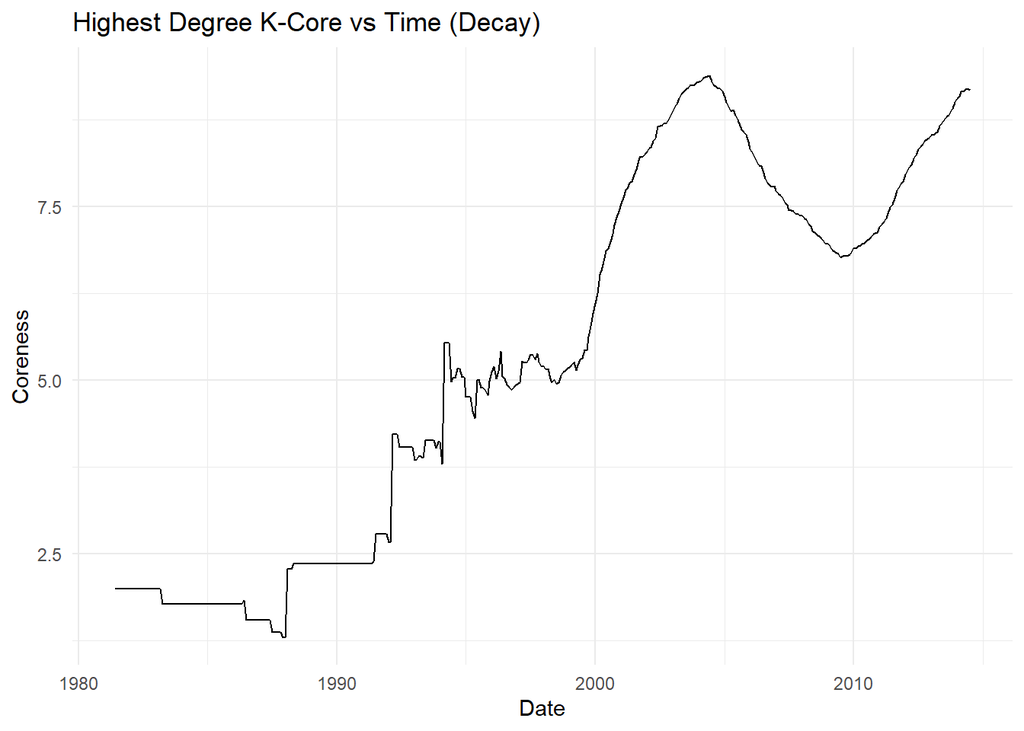

```r
#creating a dataframe for the graph to plot, with months and coreness calculated at every month
DataFrame3 <- data.frame()
Result2 <- data.frame()
for(i in 0:Length){
  Mnth <- MonthList[1]+i*(1/12)
  DataFrame3 <- WholeNtwkv2[(WholeNtwkv2$yearmon<=Mnth)&(WholeNtwkv2$yearmon>=Mnth-5)][,1:2]
  #DataFrame3 <- unique(DataFrame3) #Not Needed, the graphs are the same?
  Ntwk <- graph.data.frame(DataFrame3,directed=FALSE)
  Coreness1 <- mean(coreness(Ntwk))
  Row <- data.frame(Mnth,Coreness1)
  Result2 <- rbind(Result2,Row)
}

#plot out the graph using ggplot
ggplot() + geom_line(aes(y=Result2$Coreness1, x=Result2$Mnth)) + labs(title ="Highest Degree K-Core vs Time (Decay)", x = "Date", y = "Coreness") + theme_minimal()
```

(C) Construct a plot similar to (A), but now allow ties to “decay.” Remove ties from the network if they are not renewed within 5 years. Does the ﬁgure appear different than before? What does this suggest about the nature of relationships in the co-investment network?

Graph C is very similar to graph b, with the exception that graph c is a lot more volatile. Small changes on graph b is greatly magnified on graph c. The greatest decay period started around 2004 and lasted till around 2009, where corness rebounded and grew to over 8.0. The high volatility of graph c compared to graphs a and b confirms that there are many connections that do not get renewed after 5 years.

If we look at the nature of the network’s relationships over the years, we can see that apart from small dips, most connections are maintained, which suggests good reliability in partnerships prior to 2004. As the financial market grew out of control after 2004, many relationships began to decay away. This suggests that many firms that got screwed over during the dot-com bubble no longer works with their previous partners, and this only gets worse as the 5 year lag on decay catches up to the financial crisis. Interestingly, the decay stopped at around 2009 and rebounded. This suggests that during the time of hardship, many firms had no choice but to work with other firms that they may have previously not wanted work with. The stable growth afterwards suggests that many of these relationships were rekindled, and the network overall is growing to become more collaborative with higher coreness.

Question 3

Next, we will look at the development of the venture capital firm co-investment network in terms of its global core-periphery structure. Allow the network to be updated monthly, as in Question 3, but only consider the network that takes into account tie decay.